# Simulación

Kenneth Cabrera

31/10/2014

### Objetivos de la simulación

- Probar su intuición estadística.
- Realizar pruebas de potencia.
- Experimentar nuevas técnicas con datos conocidos.

### Simulación básica

Se pretende: - Generar datos aleatorios de una distribución conocida. - Repetir la simulación muchas veces.

### Funciones para generar número aleatorios

- `runif` (uniforme), `rpois` (poisson), `rnorm` (gausiana), `rbinom` (binomial), `rbeta` (beta), etc.
- El primer argumento sería el tamaño de muestra `n`.
- Parámetros de la distribución (Siempre verificarlos).

### Tamaño de la muestra

```r
# Generar una muestra de tamaño 100 de una gausiana(0,1)
head(m1 <- rnorm(100))
```

```
## [1]  0.8829865 -0.7655559  1.3430705 -0.5908311 -0.4958132  1.3474962
```

```r
# Generar una muestra de tamaño 10 de una beta(0.1, 0.1)
head(m2 <- rbeta(10,0.1,0.1))
```

```
## [1] 1.000000e+00 1.000000e+00 1.000000e+00 1.285634e-05 9.999995e-01
## [6] 9.999603e-01
```

### Número de simulaciones

- Se utiliza frecuentemente la función `replicate()`. `replicate(n,expression)`

```r
# 10 simulaciones de la media de muestras de tamaño 100 de gausianas(0,1)
replicate(10,mean(rnorm(100)))
```

```
##  [1]  0.0748529526  0.0037052695  0.0225825082 -0.1425234785 -0.1063329676
##  [6] -0.0939994450  0.0004790493  0.1992797297 -0.0449469892  0.1412988553
```

```
## stat_bin: binwidth defaulted to range/30. Use 'binwidth = x' to adjust this.
```

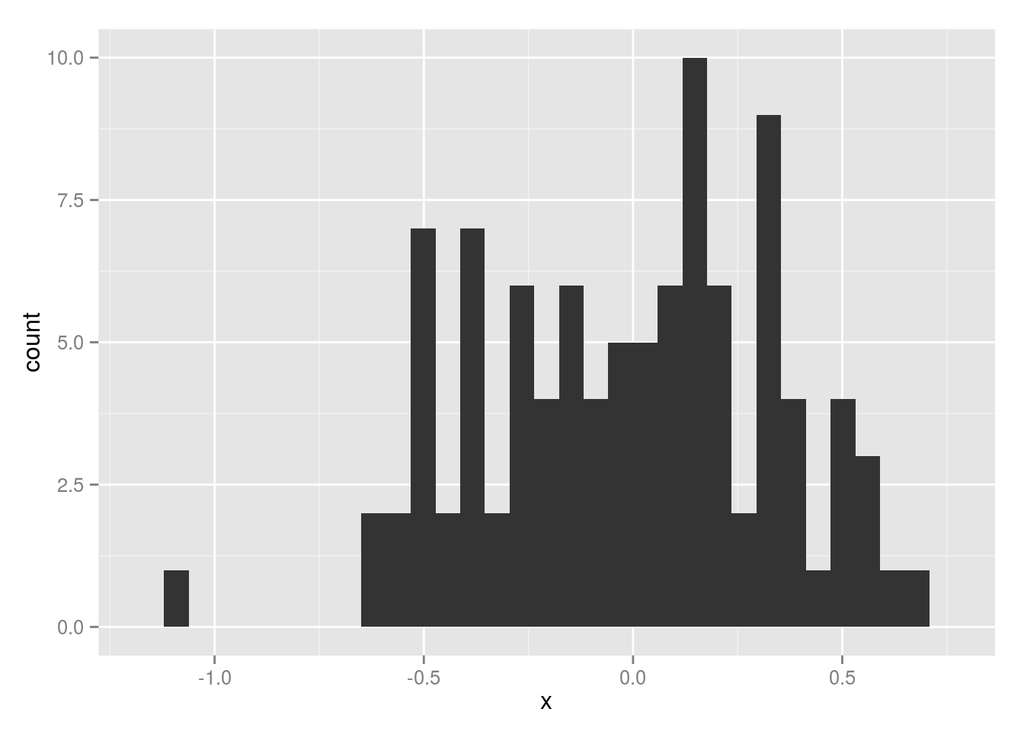

```r
# Histograma de 100 simulaciones de media de muestras de tamaño 10.
require(ggplot2)
ggplot(data.frame(x=replicate(100,mean(rnorm(10)))),aes(x)) + geom_histogram()
```

### “Solución”

```
## stat_bin: binwidth defaulted to range/30. Use 'binwidth = x' to adjust this.
```

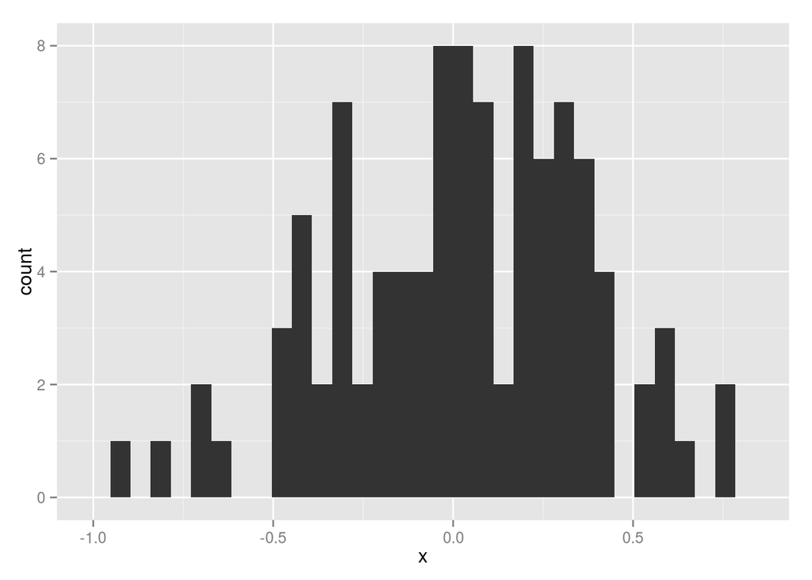

```r
require(ggplot2)
ggplot(data.frame(x=replicate(100,mean(rnorm(10)))),aes(x)) + geom_histogram()
```

```
## stat_bin: binwidth defaulted to range/30. Use 'binwidth = x' to adjust this.
```

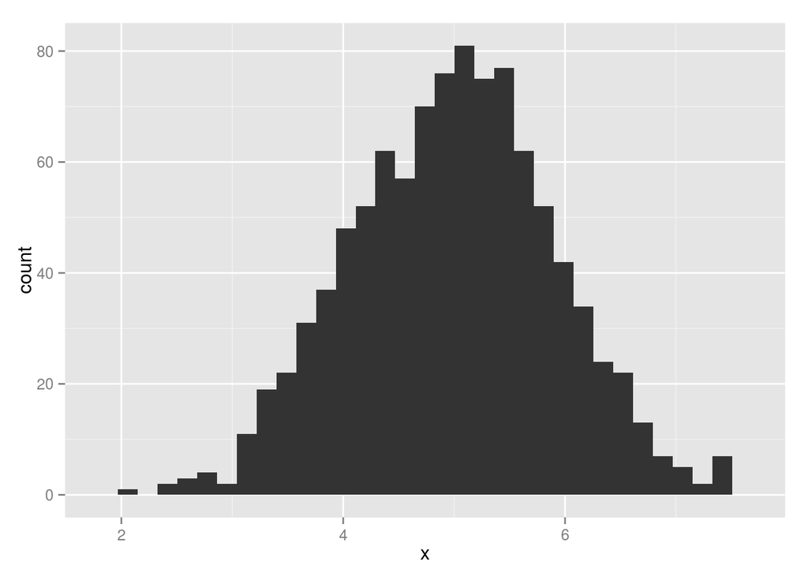

```r
ggplot(data.frame(x=replicate(1000,mean(runif(10,0,10)))),aes(x)) + geom_histogram()
```

```
## stat_bin: binwidth defaulted to range/30. Use 'binwidth = x' to adjust this.
```

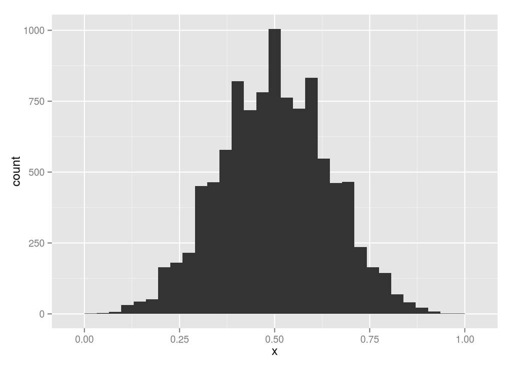

```r
ggplot(data.frame(x=replicate(10000,mean(rbeta(10,0.1,0.1)))),aes(x)) + geom_histogram()
```

### Regla DRY

Don’t Repeat Yourshelf (No se repita)

Realice una vez y sólo una vez.

- Evite incrementar la dificultad de realizar cambios.
- Incremente la claridad.
- Evite que se abran puertas a la inconsistencia.

### Use funciones

- Empiece haciéndola simple.
- Pruebe el código por fuera de la función.
- Pruebe en cada paso.
- Utilice nombres apropiados.

### Tarea 2

- Cree una función que muestre un histograma un número de simulaciones `nsim` de una normal(0,1) de muestras de tamaño 10.
- Modifique la función para que el tamaño sea `n` sea un parámetro.
- Modifique la función para que el usuario use la distribución que desee.

```
## stat_bin: binwidth defaulted to range/30. Use 'binwidth = x' to adjust this.
```

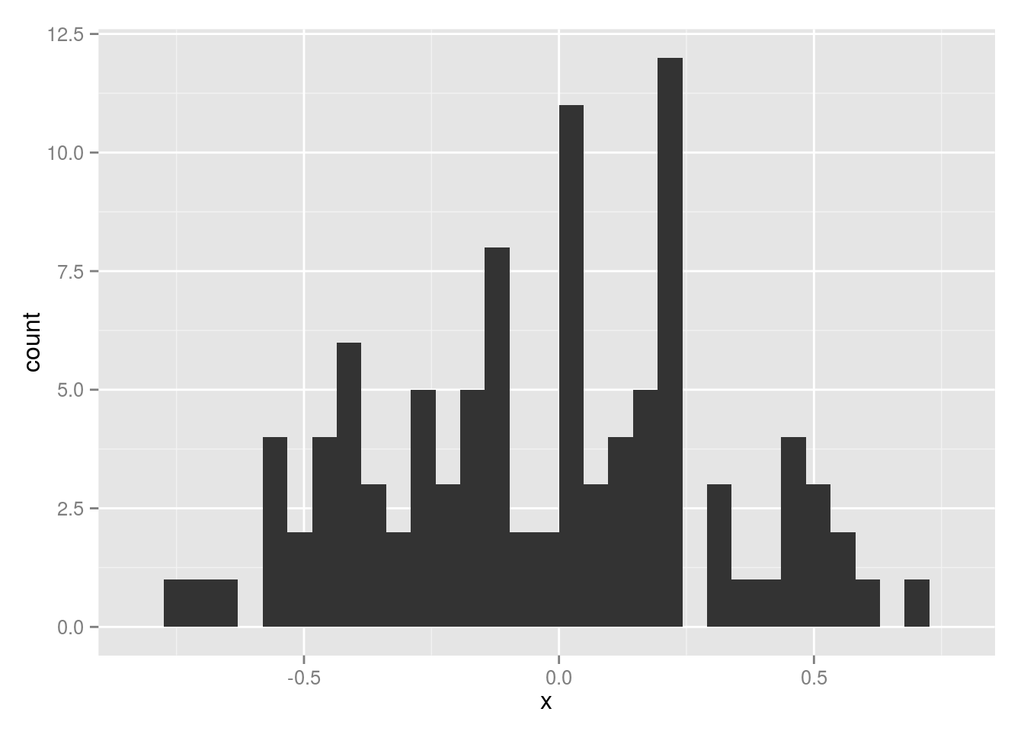

```r
histSimul1 <- function(nsim){
  bd <- data.frame(x = replicate(nsim,mean(rnorm(10))))
  require(ggplot2)
  ggplot(bd, aes(x)) + geom_histogram()
}

histSimul1(100)
```

```
## stat_bin: binwidth defaulted to range/30. Use 'binwidth = x' to adjust this.
```

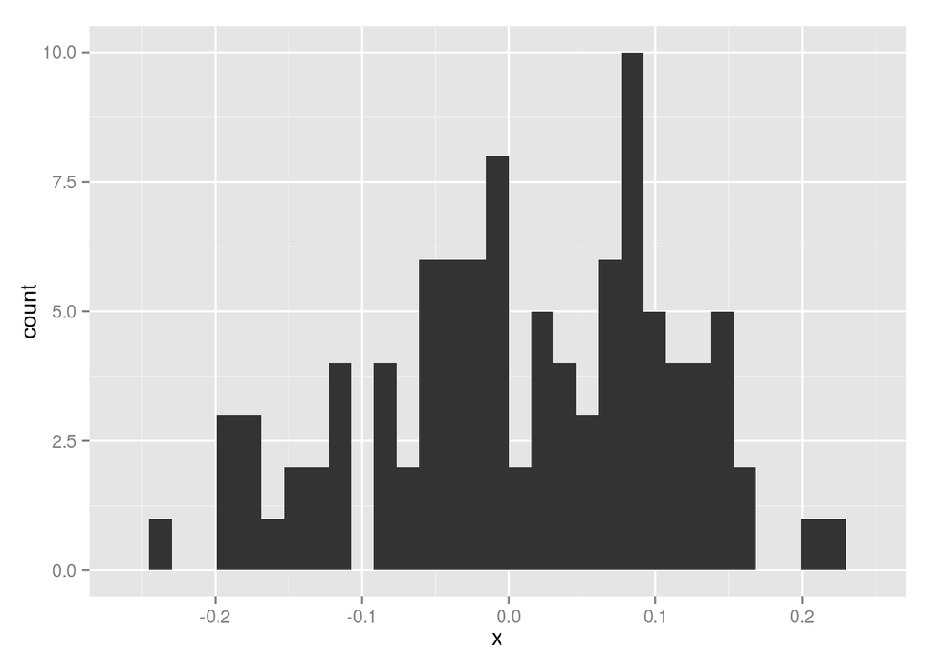

```r
histSimul2 <- function(nsim,n=100){
  bd <- data.frame(x = replicate(nsim,mean(rnorm(n))))
  require(ggplot2)
  ggplot(bd, aes(x)) + geom_histogram()
}

histSimul2(100)
```

```
## stat_bin: binwidth defaulted to range/30. Use 'binwidth = x' to adjust this.
```

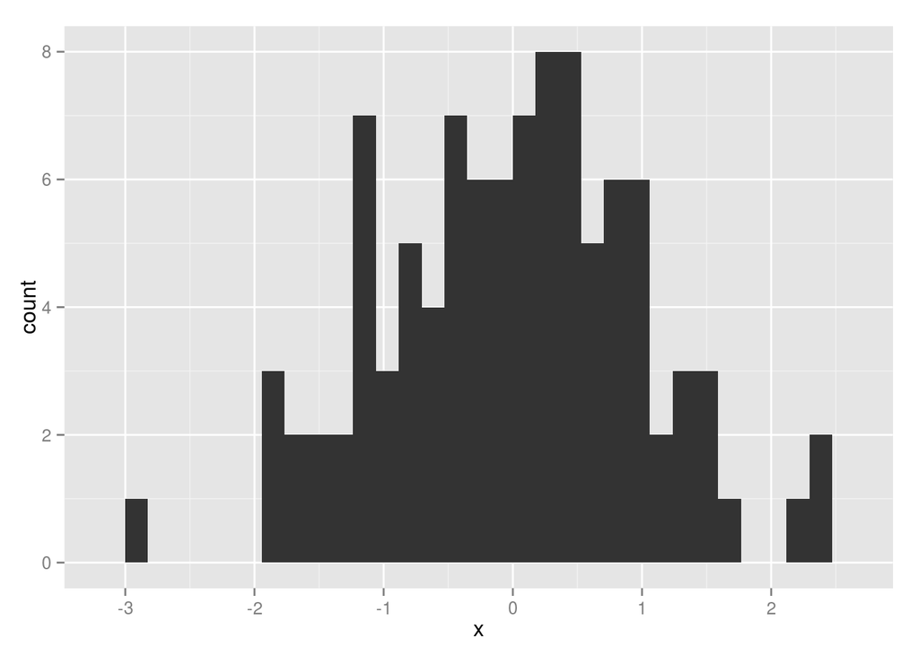

```r
histSimul2(100,1)
```

```
## stat_bin: binwidth defaulted to range/30. Use 'binwidth = x' to adjust this.
```

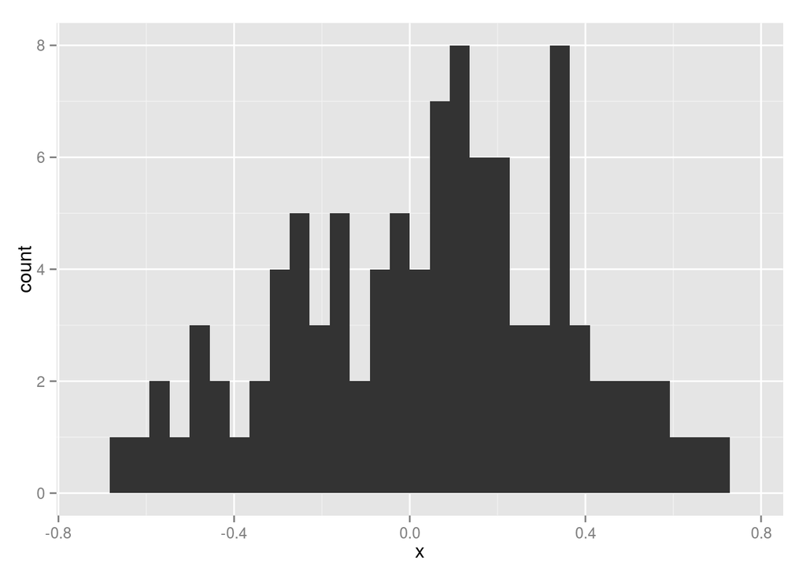

```r
histSimul3 <- function(nsim,n=10,rdistrib=rnorm,...){
  bd <- data.frame(x = vector("numeric",nsim))
  for (i in 1:nsim) bd$x[i] <- mean(rdistrib(n,...))
  require(ggplot2)
  ggplot(bd, aes(x)) + geom_histogram()
}

histSimul3(100)
```

```
## stat_bin: binwidth defaulted to range/30. Use 'binwidth = x' to adjust this.
```

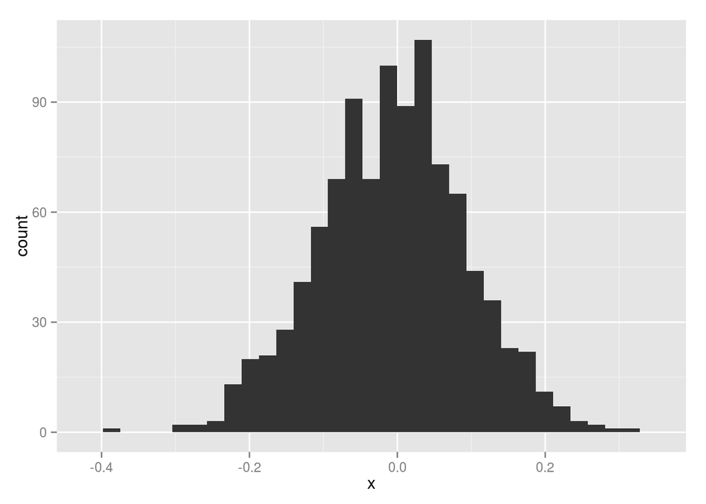

```r
histSimul3(1000,100)
```

```
## stat_bin: binwidth defaulted to range/30. Use 'binwidth = x' to adjust this.
```

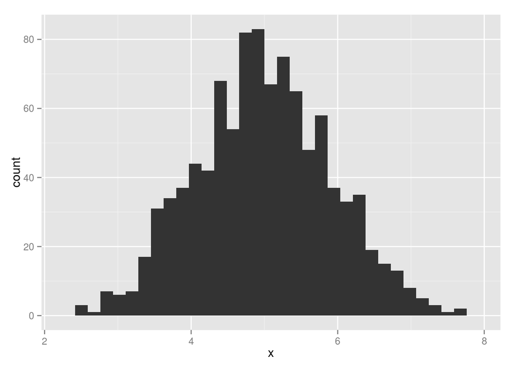

```r
histSimul3(1000,10,runif,0, 10)
```

```
## stat_bin: binwidth defaulted to range/30. Use 'binwidth = x' to adjust this.
```

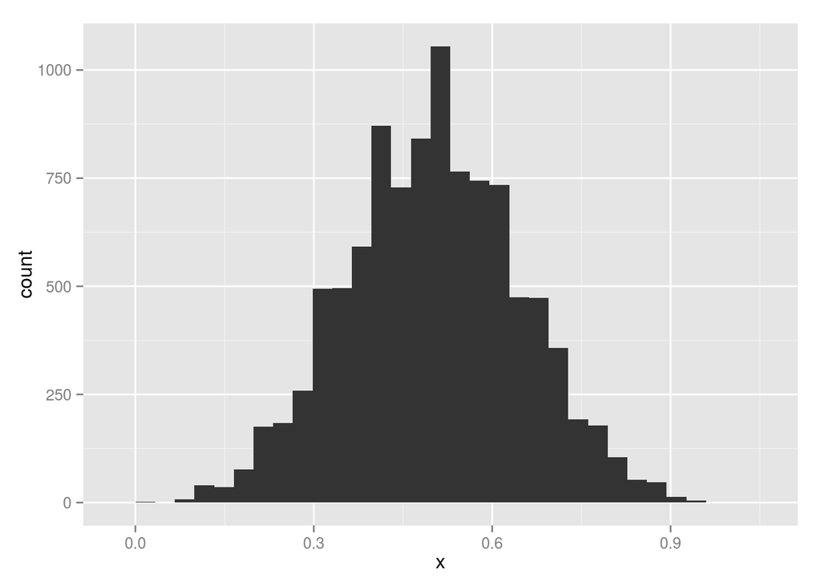

```r
histSimul3(10000,10, rbeta, 0.1, 0.1)
```

```
## stat_bin: binwidth defaulted to range/30. Use 'binwidth = x' to adjust this.
```

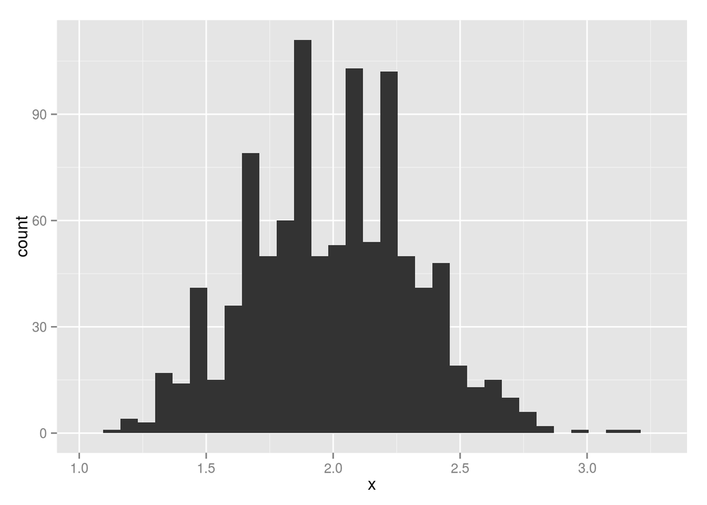

```r
histSimul3(1000,20,rpois, 2)
```